# Metformin & Analgesics

##### 본 연구는 당뇨 환자 내 암진단 환자를 target으로 한다. 다양한 변수들이 암 발생 여부와 어떠한 연관이 있는지 파악하는 것을 목표로 하며 특히, 당뇨 약제인 metformin 과 1단계 진통제(analgesics) 복용 여부와 암 발생과의 연관 관계를 중점적으로 연구하려 한다.

### 분석 전 환경 설정

- 분석에 필요한 환경 및 라이브러리를 설정한다.

```r
##Metformin Code
#options------------------------------------------------------------
rm(list=ls())
options(scipen = 100)
#R의 데이터를 올릴 수 있는 메모리 제한 해제
memory.limit(10000000000000)
gc()
#-------------------------------------------------------------------

# Package -----------------------------------------------------------
if (!require(dplyr)) install.packages('dplyr')
if (!require(comorbidity)) install.packages('comorbidity')
if (!require(data.table)) install.packages('data.table')
if (!require(reshape2)) install.packages('reshape2')
if (!require(lubridate)) install.packages('lubridate')
if (!require(bit64)) install.packages('bit64')
if (!require(readxl))  install.packages('readxl')
if (!require(finalfit)) install.packages('finalfit')
if (!require(ggplot2)) install.packages('ggplot2')
if (!require(survminer)) install.packages('survminer')
if (!require(survival)) install.packages('survival')
if (!require(Epi)) install.packages('Epi')
if (!require(broom)) install.packages('broom')
if (!require(plotrix)) install.packages('plotrix')
if (!require(gridExtra)) install.packages('gridExtra')
if (!require(ggjoy)) install.packages('ggjoy')
if (!require(naniar)) install.packages('naniar')
if (!require(psych)) install.packages('psych')
if (!require(epiDisplay)) install.packages('epiDisplay')
if (!require(oddsratio)) install.packages('oddsratio')
if (!require(GGally)) install.packages('GGally')
if (!require(ggfortify)) install.packages('ggfortify')
library(broom)
library(reshape)
select <- dplyr::select #dplyr 패키지 select함수 오류 방지
```

### Step 1. 당뇨 환자 정의 과정

- 진료DB 명세서(t20)에서 개인일련번호(PERSON_ID), 청구일련번호(KEY_SEQ), 요양개시일자(RECU_FR_DT), 주상병(MAIN_SICK), 부상병(SUB_SICK), 총처방일수(TOT_PRES_DD_CNT), 명세서서식구분(FORM_CD)을 가져온다.

```r
# 데이터 로딩----------------------------------------------------------------------------
# 20t-------------------------------------------------------------------------------------
setwd('E:\\edata\\medicaldata\\20t')
listfile <- list.files()
t20 <- list()
for(i in 1:12){t20[[i]] <- data.table::fread(listfile[i],
                                             stringsAsFactors = F,
                                             encoding = "Latin-1") %>%
  dplyr::select(PERSON_ID,
                KEY_SEQ,
                RECU_FR_DT,
                MAIN_SICK,
                SUB_SICK,
                TOT_PRES_DD_CNT,
                FORM_CD)}

t20 <- dplyr::bind_rows(t20)
length(unique(t20$PERSON_ID))
```

- 주상병/부상병으로 당뇨 코드(‘E11’,‘E12’,‘E13’,‘E14’)가 있는 INDEX_DATE, SECOND_DATE, LAST_DATE 추출
- INDEX_DATE : 당뇨 첫 진단 날짜, SECOND_DATE : 당뇨 두 번째 진단 날짜, LAST_DATE : 당뇨 진단 마지막 날짜

```r
dataframe <- t20 %>%
  dplyr::filter(substr(MAIN_SICK, 1, 3) %in% c('E11','E12','E13','E14')|
                  substr(SUB_SICK, 1, 3) %in% c('E11','E12','E13','E14')) %>%
  dplyr::group_by(PERSON_ID) %>%
  dplyr::summarise(INDEX_DATE = min(RECU_FR_DT),
                   SECOND_DATE = dplyr::nth(RECU_FR_DT, 2),
                   LAST_DATE = max(RECU_FR_DT))

t20 <- t20 %>% filter(PERSON_ID %in% dataframe$PERSON_ID)
```

##### 조건 1. 당뇨 2회 이상 진단 받은 환자

- na.omit()를 하는 이유 : 두 번째 진단 날짜 값이 결측값이 경우, 즉 첫 번째 진단만 받은 경우를 제거하므로써, 당뇨 진단 2회 이상 진단 받은 환자만 남게 됨

```r
dataframe1 <- dataframe %>% na.omit()
```

##### 조건 2. 당뇨 진단 + 당뇨 약제 처방

- 진료DB(t20)에 당뇨 진단 기록이 있으면서, 처방전교부상세내역(t60)에서 당뇨약제 처방도 받은 환자
- 먼저, 처방전교부상세내역(t60)에서 청구일련번호(KEY_SEQ), 요양개시일자(RECU_FR_DT), 약일반명코드(GNL_NM_CD), 총투여일수(MDCN_EXEC_FREQ)를 불러온다.
- 청구일렬번호(KEY_SEQ)가 dataframe과 t20, t60을 연결시켜주는 unique_key 이므로, filter 해줌

```r
# 위에서 추출한 당뇨코드가 발생한 전체 환자(dataframe)를 filter
t20 <- t20 %>% filter(PERSON_ID %in% dataframe$PERSON_ID)

setwd('E:\\edata\\medicaldata\\60t')
listfile <- list.files()
t60 <- list()
for(i in 1:12){t60[[i]] <- data.table::fread(listfile[i]) %>%
  dplyr::select(KEY_SEQ,
                RECU_FR_DT,
                GNL_NM_CD,
                MDCN_EXEC_FREQ) %>%
  dplyr::filter(KEY_SEQ %in% t20$KEY_SEQ)}
t60 <- dplyr::bind_rows(t60)
```

- 당뇨 약제정보가 기록되어 있는 csv 파일을 불러와서, 전체 처방 기록(t60)에서 당뇨약제 처방 기록이 있는 자료 filter
- 여기서, t60의 약일반명코드(GNL_NM_CD)의 앞의 4자리가 약제파일 code의 앞의 4자리가 동일하면 같은 약제

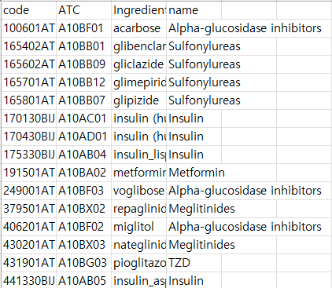

- 당뇨를 한번이라도 진단 받은 환자 (dataframe)에서 당뇨 약제 처방 기록이 있는 환자 다시 한 번 filter

```r
# 당뇨 약제 파일 #
medicine_d <- read.csv('E:\\metformin_seo\\diabetes_m.csv')
medicine_d <- medicine_d %>% dplyr::select(code,name)
medicine_d <- medicine_d %>%
  dplyr::mutate(ATC_CAT = substr(code, 1, 4)) %>%
  unique()
# t60 에서 당뇨약제 처방 받은 환자 기록만 추출하기
t60_d <- t60 %>%
  dplyr::mutate(ATC_CAT = substr(GNL_NM_CD, 1, 4)) %>%
  dplyr::filter(ATC_CAT %in% medicine_d$ATC_CAT) %>%
  dplyr::inner_join(medicine_d) %>%
  dplyr::left_join(t20 %>%
                     dplyr::select(PERSON_ID,
                                   KEY_SEQ))
# 당뇨 진단 받은 환자 & 당뇨약제 처방받은 기록있는 환자
dataframe2 <- dataframe %>% filter(PERSON_ID %in% t60_d$PERSON_ID)
```

#### 최종 당뇨환자

- 조건 1과 조건 2 중 하나라도 해당되면 당뇨환자로 정의

```r
dataframe <- rbind(dataframe1, dataframe2) %>% unique()
rm(dataframe1, dataframe2)
```

### Step 2. 암환자 정의

- 먼저, 진료DB명세서(t20)에서 주상병(MAIN_SICK)에 암코드(첫 글자가 ’C")가 있는 모든 자료 filter 후, 환자 별(PERSON_ID)로 요양개시일자(RECU_FR_DT)와 주상병(MAIN_SICK) 이 있는 리스트로 spilt

```r
cancer <- t20 %>% filter(substr(MAIN_SICK,1,1) == 'C') %>% arrange(PERSON_ID, RECU_FR_DT)
length(unique(cancer$PERSON_ID))      #14425

cancer1 <- cancer %>% select(PERSON_ID, RECU_FR_DT, MAIN_SICK)
c_list <- split(cancer1, cancer1$PERSON_ID)
```

##### 기준 1. 1년 내 동일한 암을 3번 이상 진단 반은 환자

- 1년 내 진료DB 명세서(t20)에 있는 주상병 코드(MAIN_SICK)에서 동일한 암코드가 3회 이상 발생
- 여기서 암이 발생한 날짜는 동일한 암코드가 발생한 첫번째 날짜로 취급

```r
### 정의 1 함수
# 15분 정도 걸림
case <- function(data,freq,term) {
  idlist <- c()
  n = freq-1

  for(i in 1:length(data)){
    id <- data[[i]]
    list <- c()

    # freq 간격 내 기간이 term 이내인 환자를 return 함
    #  ex. 3번의 암 진단을 받을 때까지의 기간이 365 일 이내이면 return -> 정의 1을 거꾸로 생각함
    for(j in 1:(nrow(id) - n)) {
      list[j] <- as.numeric(ymd(id$RECU_FR_DT[j+n]) - ymd(id$RECU_FR_DT[j]))
      if(sum(list <= term, na.rm = T) >= 1) {

        for(k in 1:length(list)) {
          idlist[[i]] <- id[k]
          # 1. 1년 내 3번의 암코드가 발생했고, 2. 3번의 암코드가 동일한 경우
          if((list[k] <= term) & (length(unique(c(id$MAIN_SICK[k], id$MAIN_SICK[k+1], id$MAIN_SICK[k+2]))) == 1)) break
        }
      }
    }
  }
  return(idlist)
}

# 1년(365) 이내에 암 코드가 3회 이상 출현한 환자
cancer1 <- case(c_list, 3, 365)
cancer1 <- bind_rows(cancer1)

length(unique(cancer1$PERSON_ID))

cancer1 <- cancer1 %>% select(-c(MAIN_SICK))
colnames(cancer1) = c('PERSON_ID', 'CANCER_DATE')
```

##### 기준 2 : 암코드와 함께 입원이 동시에 발생한 경우

- 여기서, FORM_CD 에서 (2,4,6,7,10,12) 는 입원 관련 코드

```r
cancer2 <- cancer %>% filter(substr(MAIN_SICK, 1, 1) == 'C' & FORM_CD %in% c(2,4,6,7,10,12))
length(unique(cancer2$PERSON_ID))

cancer2 <- cancer2 %>% select(c('PERSON_ID', 'RECU_FR_DT'))
colnames(cancer2) = c('PERSON_ID', 'CANCER_DATE')
```

#### 최종 암 진단 환자 : 조건1 + 조건2

- 여기서, 암 발생일(INDEX_CANCER)은 가장 처음 발견된 날짜로 정의

```r
cancer <- bind_rows(cancer1 %>% select(PERSON_ID, CANCER_DATE), cancer2 %>% select(PERSON_ID, CANCER_DATE)) %>%
  group_by(PERSON_ID) %>% summarise(INDEX_CANCER = min(CANCER_DATE))
length(unique(cancer$PERSON_ID))

cancerand <- dataframe %>% filter(PERSON_ID %in% cancer1$PERSON_ID &
                                    PERSON_ID %in% cancer2$PERSON_ID) # 조건 두 개가 겹치는 환자는 8409명

# df 에 암 변수(CD), 암발생 날짜(INDEX_CANCER) 추가
dataframe <- dataframe %>% mutate(CD = ifelse(PERSON_ID %in% cancer$PERSON_ID, 1, 0),
                                  INDEX_CANCER = ifelse(PERSON_ID %in% cancer$PERSON_ID, cancer$INDEX_CANCER, NA))
```

### Step 3. 분석에 필요한 변수 설정

- 자격 DB(jk)에서 기준년도(STND_Y), 환자고유번호(PERSON_ID), 성별(SEX), 나이(AGE_GRUOP), 소득분위(CTRB_PT_TYPE_CD), 사망년월(DTH_YM) 불러온 뒤, 당뇨 첫 진단 년도 당시 자격 정보와 dataframe 을 결합

```r
# jk  ---------------------------------------------------------------------
# 나이 정보를 위해 자격 데이터 로딩
setwd('E:\\edata\\medicaldata\\jk')
listfile <- list.files()
jk <- list()
for(i in 1:12){jk[[i]] <- data.table::fread(listfile[i]) %>%
  dplyr::filter(PERSON_ID %in% dataframe$PERSON_ID)}
jk <- dplyr::bind_rows(jk)
jk_age <- jk %>%
  dplyr::select(STND_Y, PERSON_ID, SEX, AGE_GROUP, CTRB_PT_TYPE_CD, DTH_YM)
#index date 당시 jk 데이터 결합
dataframe <- dataframe %>%
  dplyr::mutate(STND_Y = as.numeric(substr(INDEX_DATE, 1, 4))) %>%
  dplyr::inner_join(jk_age)
```

#### 코호트 추적 기간(duration) 정의

- 암환자 : 암 발생 날짜(INDEX_CANCER) - 당뇨 첫 진단일(INDEX_DATE)
- 사망환자: 사망날짜(DTH_DATE) - 당뇨 첫 진단일(INDEX_DATE)
- 생존환자: 코호트 마지막날짜(20131231) - 당뇨 첫 진단일(INDEX_DATE)

```r
t20 <- t20 %>% filter(PERSON_ID %in%dataframe$PERSON_ID)
t20_last <- t20 %>% group_by(PERSON_ID) %>% summarise(FINAL_DATE = max(RECU_FR_DT))

dataframe <- dataframe %>% left_join(t20_last)
dataframe$DTH_YM <- NULL

# 사망한 환자들 정보를 불러와서,
jk_DTH <- jk %>% filter(is.na(DTH_YM) == F)
dataframe.dth <- dataframe %>% filter(PERSON_ID %in% jk_DTH$PERSON_ID)
dataframe.dth <- dataframe.dth %>% left_join(jk_DTH %>% dplyr::select(PERSON_ID, DTH_YM))
# 마지막 내원날짜와 사망년월이 동일하면 마지막 내원 날짜(final_date)로, 아니면 사망년월(DTH_YM) 에 15일을 추가해 사망일자 생성
dataframe.dth <- dataframe.dth %>% mutate(DTH_DATE = ifelse(substr(FINAL_DATE, 1, 6) == DTH_YM,
                                                            FINAL_DATE, as.integer(paste0(DTH_YM,15))))
dataframe <- dataframe %>% left_join(dataframe.dth %>% select(PERSON_ID, DTH_DATE))

## duration
# 1) INDEX_CANCER 2) DTH_DATE 3) 20131231
str(dataframe)
dataframe1 <- dataframe %>% filter(CD == 1) %>% mutate(duration = as.integer(ymd(INDEX_CANCER) - ymd(INDEX_DATE)))
dataframe2 <- dataframe %>% filter(CD == 0) %>% mutate(duration = ifelse(is.na(DTH_DATE) == F, as.integer(ymd(DTH_DATE) - ymd(INDEX_DATE)),
                                                                         as.integer(ymd(20131231) - ymd(INDEX_DATE))))
dataframe <- bind_rows(dataframe1,dataframe2)
```

- 검진자료 DB를 불러와서 건강상태 관련 변수 추가
- 주의사항 : 검진자료의 문항이 2009년부터 달라져 속성이 안맞으므로, 두 덩이로 쪼개서 불러온 뒤 data type 을 맞춰주고 합쳐야함

```r
path <- "E:\\edata\\medicaldata\\gj\\"
filelist <- list.files(path)
gj <- list()
for (i in 1:7) {
  gj[[i]] <- fread(paste0(path, filelist[i]),
                   stringsAsFactors = F,
                   encoding = "Latin-1") %>%
    mutate(WAIST = NA,
           TRIGLYCERIDE = NA,
           HDL_CHOLE = NA,
           LDL_CHOLE = NA,
           CREATININE = NA,
           MOV20_WEK_FREQ_ID = NA,
           MOV30_WEK_FREQ_ID = NA,
           WLK30_WEK_FREQ_ID = NA) %>%
    dplyr::select(PERSON_ID,
                  HCHK_YEAR,
                  HEIGHT, WEIGHT,
                  WAIST,
                  BP_HIGH, BP_LWST,
                  BLDS,
                  TOT_CHOLE, TRIGLYCERIDE, HDL_CHOLE, LDL_CHOLE,
                  HMG,
                  OLIG_PROTE_CD,
                  CREATININE, SGOT_AST, SGPT_ALT, GAMMA_GTP,
                  SMK_STAT_TYPE_RSPS_CD, DRNK_HABIT_RSPS_CD,
                  EXERCI_FREQ_RSPS_CD)
}
for (i in 8:length(filelist)) {
  gj[[i]] <- fread(paste0(path, filelist[i]),
                   stringsAsFactors = F,
                   encoding = "Latin-1") %>%
    mutate(EXERCI_FREQ_RSPS_CD = NA) %>%
    dplyr::select(PERSON_ID,
                  HCHK_YEAR,
                  HEIGHT, WEIGHT,
                  WAIST,
                  BP_HIGH, BP_LWST,
                  BLDS,
                  TOT_CHOLE, TRIGLYCERIDE, HDL_CHOLE, LDL_CHOLE,
                  HMG,
                  OLIG_PROTE_CD,
                  CREATININE, SGOT_AST, SGPT_ALT, GAMMA_GTP,
                  SMK_STAT_TYPE_RSPS_CD, DRNK_HABIT_RSPS_CD,
                  MOV20_WEK_FREQ_ID, MOV30_WEK_FREQ_ID, WLK30_WEK_FREQ_ID)
}
rm(filelist, i, path)
gj <- bind_rows(gj) %>%
  arrange(PERSON_ID, HCHK_YEAR) %>%
  filter(PERSON_ID %in% dataframe$PERSON_ID)
```

- baseline(index_date) 이후 첫 검진 자료 추출

```r
gj <- gj %>% left_join(dataframe %>% select(PERSON_ID, INDEX_DATE))
gj <- gj %>% filter(HCHK_YEAR >= year(ymd(INDEX_DATE)))
gj1 <- gj %>% group_by(PERSON_ID) %>% summarise(FIRST_YEAR = min(HCHK_YEAR))
gj <- gj %>% left_join(gj1) %>% filter(HCHK_YEAR == FIRST_YEAR)
rm(gj1)

dataframe <- dataframe %>% left_join(gj %>% select(-c(INDEX_DATE)), by = "PERSON_ID")
```

#### BMI, Alcohol, Smoke, Exercise

- BMI : 몸무게 / ((키/100) ** 2)
- Alcohol : 2009년 기준으로 관련 문항이 변경(코드표 참조) -> 0 : no, 1 : 종종, 2: 자주

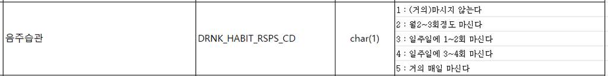

  2009년 이전

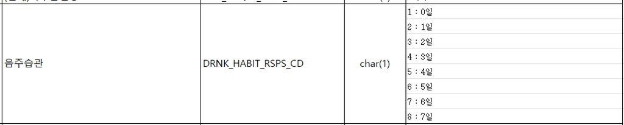

  2009년 이후

- smoke : 현재 흡연상태 -> 1: x , 2: 금연 , 3: 흡연

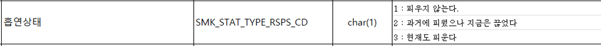

- exercise : 2009년 기준으로 관련 문항이 변경(코드표 참조) -> 0: no, 1: 종종, 2: 자주

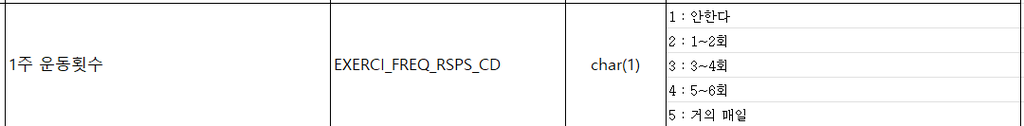

  2009년 이전

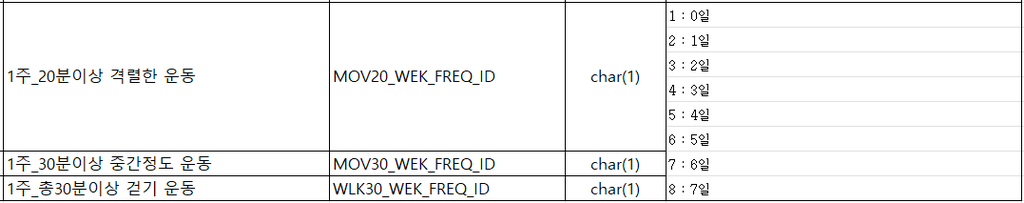

  2009년 이후

```r
# BMI
dataframe <- dataframe %>% mutate(BMI = WEIGHT / (HEIGHT/100)**2)
# alcohol
dataframe <- dataframe %>%
  mutate(Alcohol = ifelse(HCHK_YEAR >= 2009 & DRNK_HABIT_RSPS_CD ==1, 0,
                          ifelse(HCHK_YEAR >= 2009 & DRNK_HABIT_RSPS_CD <8, 1,
                                 ifelse(HCHK_YEAR >= 2009 & DRNK_HABIT_RSPS_CD ==8, 2,
                                        ifelse(HCHK_YEAR < 2009 & DRNK_HABIT_RSPS_CD ==1, 0,
                                               ifelse(HCHK_YEAR < 2009 & DRNK_HABIT_RSPS_CD <5, 1,
                                                      ifelse(HCHK_YEAR < 2009 & DRNK_HABIT_RSPS_CD ==5, 2, NA)))))))
# smoke
dataframe$Smoking <- dataframe$SMK_STAT_TYPE_RSPS_CD
# exercise
dataframe <- dataframe %>%
  mutate(Exer = ifelse(HCHK_YEAR >= 2009 & (MOV20_WEK_FREQ_ID %in% c(7,8) | MOV30_WEK_FREQ_ID %in% c(7,8) | WLK30_WEK_FREQ_ID %in% c(7,8)), 2,
                       ifelse(HCHK_YEAR >= 2009 & (MOV20_WEK_FREQ_ID %in% c(2,3,4,5,6) | MOV30_WEK_FREQ_ID %in% c(2,3,4,5,6) | WLK30_WEK_FREQ_ID %in% c(2,3,4,5,6)), 1,
                              ifelse(HCHK_YEAR >= 2009 & MOV20_WEK_FREQ_ID == 1 & MOV30_WEK_FREQ_ID == 1 & WLK30_WEK_FREQ_ID == 1, 0,
                                     ifelse(HCHK_YEAR < 2009 & EXERCI_FREQ_RSPS_CD == 5, 2,
                                            ifelse(HCHK_YEAR < 2009 & EXERCI_FREQ_RSPS_CD %in% c(2,3,4), 1,
                                                   ifelse(HCHK_YEAR < 2009 & EXERCI_FREQ_RSPS_CD == 1, 0, NA)))))))
table(dataframe$Exer)
```

#### CCI score 정의

- 동반질환지수 : 동반질환으로 인한 중증도를 보정하기 위해 만들어진 척도, 진단 시점 이전의 의료이요 내역을 기반하여 17개 동반질환에 대해 가중치를 부여하여 합산함
- 먼저 진료DB 상병내역(t40)을 불러옴
- t40은 PERSON_ID 존재하므로, dataframe 에 존재하는 PERSON_ID만 filter

```r
# t40 ---------------------------------------------------------------------
t20 <- t20 %>% filter(PERSON_ID %in% dataframe$PERSON_ID)
setwd('E:\\edata\\medicaldata\\40t')
listfile <- list.files()
t40 <- list()
for(i in 1:12){t40[[i]] <- data.table::fread(listfile[i]) %>%
  dplyr::select(KEY_SEQ,
                RECU_FR_DT,
                SICK_SYM) %>%
  dplyr::filter(KEY_SEQ %in% t20$KEY_SEQ)}
t40 <- dplyr::bind_rows(t40) %>%
  dplyr::inner_join(t20 %>%
                      dplyr::select(PERSON_ID,
                                    KEY_SEQ)) %>%
  dplyr::filter(PERSON_ID %in% dataframe$PERSON_ID) %>%
  dplyr::arrange(PERSON_ID)
t40$RECU_FR_DT <- lubridate::ymd(t40$RECU_FR_DT)
```

- t40에 당뇨 첫 진단일(index_date)과 첫 검진년도(fisrt_year) 붙여주고, 검진년도로부터 1년전 자료만 filter
- 검진 받은 년도 기준 1년 전 자료로만 CCI score 계산하기 위함
- 여기서, 당뇨 관련 질환은 제외 -> 대상 환자들이 당뇨환자들이므로, 동반질환지수를 계산할때 제외함
- 점수에 따라 4그룹으로 분류 -> t40 에 자료가 없는 환자는 동반질환이 발생하지 않은 환자이므로, 0으로 취급

```r
# t40에 FIRST_YEAR 붙여서, 1년 전 데이터 필터
t40_CCI <- t40 %>% left_join(dataframe %>% select(PERSON_ID, INDEX_DATE, FIRST_YEAR))
t40_CCI <- t40_CCI %>% filter(year(RECU_FR_DT) == FIRST_YEAR - 1)
length(unique(t40_CCI$PERSON_ID))
# t40에서 상병기호(SICK_SYM)가 당뇨/당뇨합병증('E11','E12','E13','E14')인 기록 제거 후, 계산
t40_CCI <- t40_CCI %>%
  filter(!substr(SICK_SYM, 1, 3) %in% c('E11','E12','E13','E14'))
score <- comorbidity::comorbidity(t40_CCI,
                                  id = 'PERSON_ID',
                                  code = 'SICK_SYM',
                                  score = 'charlson',
                                  icd = 'icd10',
                                  assign0 = FALSE)
CCI <- score %>%
  select(PERSON_ID, wscore) %>%
  dplyr::rename(cci = wscore) %>%
  mutate(cci_cat = ifelse(cci == 0, 0,
                          ifelse(cci == 1, 1,
                                 ifelse(cci == 2, 2, "3+"))))
CCI$PERSON_ID <- as.numeric(CCI$PERSON_ID)
# 여기서, 첫검진년도 1년 전까지의 t40 자료가 없는 환자들은 0으로 부여
dataframe <- dataframe %>% left_join(CCI)
dataframe <- dataframe %>% mutate(CCI = ifelse(is.na(cci), 0, cci),
                                  CCI_CAT = ifelse(is.na(cci_cat), 0, cci_cat))
rm(t40, t40_CCI, CCI, gj)
table(dataframe$CCI_CAT)
table(dataframe$SEX)
```

#### 고지혈증, 류마티스관절염 정의

- 주/부상병에서 각 질병 관련 코드가 발생한 환자의 경우로 정의

```r
hyperlipidemia <- t20 %>%
  dplyr::filter(substr(MAIN_SICK, 1, 4) %in% c('E780','E781','E782','E783', 'E784', 'E785') |
                  substr(SUB_SICK, 1, 4) %in% c('E780','E781','E782','E783', 'E784', 'E785')) %>%
  dplyr::group_by(PERSON_ID)
dataframe <- dataframe %>% mutate(hyperlip = ifelse(PERSON_ID %in% hyperlipidemia$PERSON_ID, 1, 0))

arthritis <- t20 %>%
  dplyr::filter(substr(MAIN_SICK, 1, 3) %in% c('M05','M06','M07','M08', 'M09', 'M10', 'M11', 'M12', 'M13', 'M14') |
                  substr(SUB_SICK, 1, 3) %in% c('M05','M06','M07','M08', 'M09', 'M10', 'M11', 'M12', 'M13', 'M14')) %>%
  dplyr::group_by(PERSON_ID)
dataframe <- dataframe %>% mutate(arth = ifelse(PERSON_ID %in% arthritis$PERSON_ID, 1, 0))
```

#### 고혈압 정의

##### 조건 1. index_date 이후부터 첫 검진날짜까지 주상병, 부상병에서 고혈압 코드 (‘I10’, ‘I11’, ‘I12’, ‘I13’, ‘I15’) 가 발견된 환자

```r
t20 <- t20 %>% left_join(dataframe %>% select(PERSON_ID, INDEX_DATE, FIRST_YEAR))
hyper1 <- t20 %>%
  dplyr::filter(ymd(RECU_FR_DT) >= ymd(INDEX_DATE) & year(ymd(RECU_FR_DT)) <= FIRST_YEAR) %>%
  dplyr::filter(substr(MAIN_SICK, 1, 3) %in% c('I10', 'I11', 'I12', 'I13', 'I15')|
                  substr(SUB_SICK, 1, 3) %in% c('I10', 'I11', 'I12', 'I13', 'I15'))
dataframe <- dataframe %>% mutate(hyper = ifelse(PERSON_ID %in% hyper1$PERSON_ID, 1, 0))
table(dataframe$hyper)
```

##### 조건 2. index_date 이후 첫 검진자료에서 수축기협압(140) or 이완기 혈압 (90) or 과거병력코드(4.고혈압)

- 검진 자료에서 수축기혈압(BP_HIGH), 이완기혈압(BP_LWST), 과거병력코드(HCHK_PMH_CD1,HCHK_PMH_CD2,HCHK_PMH_CD3)를 불러와 정의
- 2009년 기준으로 과거병력코드 관련 문항이 변경되어 고려해서 정의함

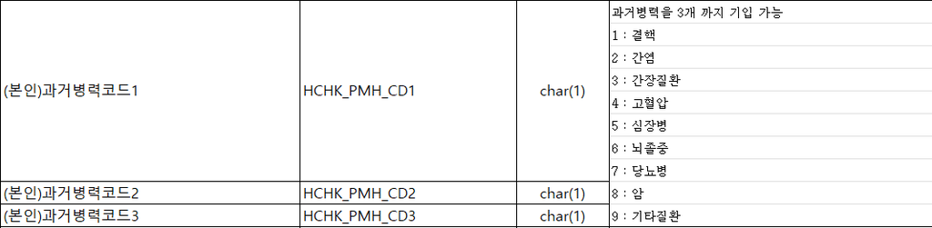

  2009년 이전

```r
path <- "E:\\edata\\medicaldata\\gj\\"
filelist <- list.files(path)
gj <- list()
for (i in 1:7) {
  gj[[i]] <- fread(paste0(path, filelist[i]),
                   stringsAsFactors = F,
                   encoding = "Latin-1") %>%
    mutate(HCHK_HPRTS_PMH_YN = NA) %>%
    dplyr::select(PERSON_ID,
                  HCHK_YEAR,
                  BP_HIGH, BP_LWST,
                  HCHK_PMH_CD1,HCHK_PMH_CD2,HCHK_PMH_CD3)
}
for (i in 8:length(filelist)) {
  gj[[i]] <- fread(paste0(path, filelist[i]),
                   stringsAsFactors = F,
                   encoding = "Latin-1") %>%
    mutate(HCHK_PMH_CD1 = NA,
           HCHK_PMH_CD2 = NA,
           HCHK_PMH_CD1 = NA) %>%
    dplyr::select(PERSON_ID,
                  HCHK_YEAR,
                  BP_HIGH, BP_LWST,
                  HCHK_HPRTS_PMH_YN)
}
rm(filelist, i, path)
gj <- bind_rows(gj) %>%
  arrange(PERSON_ID, HCHK_YEAR) %>%
  filter(PERSON_ID %in% dataframe$PERSON_ID)
length(unique(gj$PERSON_ID))
# baseline(index_date)이후 첫 검진 자료 추출
gj <- gj %>% left_join(dataframe %>% select(PERSON_ID, INDEX_DATE))
gj <- gj %>% filter(HCHK_YEAR >= year(ymd(INDEX_DATE)))
gj1 <- gj %>% group_by(PERSON_ID) %>% summarise(FIRST_YEAR = min(HCHK_YEAR))
gj <- gj %>% left_join(gj1) %>% filter(HCHK_YEAR == FIRST_YEAR)
rm(gj1)

gj <- gj %>% dplyr::filter(BP_HIGH >= 140 |
                             BP_LWST >= 90 |
                             HCHK_PMH_CD1 == 4 |
                             HCHK_PMH_CD2 == 4 |
                             HCHK_PMH_CD3 == 4 |
                             HCHK_HPRTS_PMH_YN == 1)
dataframe <- dataframe %>% mutate(hyper = ifelse(PERSON_ID %in% gj$PERSON_ID, 1, hyper))
table(dataframe$hyper)
```

#### metformin 정의

- 전체 처방 기록(t60)에서 당뇨약제 파일 내 metformin 에 관련된 정보들만 filter

```r
t20 <- t20 %>% filter(PERSON_ID %in% dataframe$PERSON_ID)
t60 <- t60 %>% filter(KEY_SEQ %in% t20$KEY_SEQ)

medicine_d <- read.csv('E:\\metformin_seo\\diabetes_m.csv')
medicine_d <- medicine_d %>% dplyr::select(code,name)
medicine_d <- medicine_d %>%
  dplyr::mutate(ATC_CAT = substr(code, 1, 4)) %>%
  unique()

# t60 에서 당뇨약제 처방 받은 환자 기록만 추출하기
t60_d <- t60 %>%
  dplyr::mutate(ATC_CAT = substr(GNL_NM_CD, 1, 4)) %>%
  dplyr::filter(ATC_CAT %in% medicine_d$ATC_CAT) %>%
  dplyr::inner_join(medicine_d) %>%
  dplyr::left_join(t20 %>%
                     dplyr::select(PERSON_ID,
                                   KEY_SEQ))
```

##### metformin 정의는 두가지 방법으로 고려하여 총 5가지 방법으로 정의

1. 설정기간 내 총 처방일수 180일 기준으로 non-adherent, adherent (처방기록이 없으면 never)
2. mpr(mpr = 설정 기간내 총처방일수 / 설정 기간) 기준으로 0.8 이상이면 non-adherent, adherent (처방기록이 없으면 never)
- 여기에 당뇨 첫 진단일 이후 1) 1년 기준, 2) 2년 기준 3) 총 처방 기간 기준으로 나누어 총 5가지 기준을 고려
1. 1년 기준 총처방일수 180일 기준
2. 1년 기준 mpr (즉, 1년 내 총 처방일수 / 365)
3. 2년 기준 총처방일수 180일
4. 2년 기준 mpr (즉, 2년 내 총 처방일수 / 730)
5. 당뇨 첫 진단일 이후 총 처방기간 기준 mpr (즉, 총처방기간 내 총 처방일수 / 총처방기간)

```r
met <- t60_d %>% filter(grepl('Metformin', name)) %>%
  inner_join(t20 %>% dplyr::select(PERSON_ID, KEY_SEQ, RECU_FR_DT, TOT_PRES_DD_CNT)) %>%
  arrange(PERSON_ID)
length(unique(met$PERSON_ID))
met_duration <- met %>% group_by(PERSON_ID) %>% summarise(firstmet = min(RECU_FR_DT), lastdate = max(RECU_FR_DT))
met_duration <- met_duration %>% mutate(pd = as.integer(ymd(lastdate) - ymd(firstmet)))

# mpr 기준
met <- met %>% left_join(met_duration)
met <- met %>% left_join(dataframe %>% dplyr::select(PERSON_ID, INDEX_CANCER, INDEX_DATE, duration))

# 설정 기간 기준
met1 <- met %>% filter(ymd(RECU_FR_DT) - ymd(INDEX_DATE) >= 0)
met1 <- met1 %>% filter(ymd(RECU_FR_DT) - ymd(INDEX_DATE) <= 365)

met2 <- met %>% filter(ymd(RECU_FR_DT) - ymd(INDEX_DATE) >= 0)
met2 <- met2 %>% filter(ymd(RECU_FR_DT) - ymd(INDEX_DATE) <= 365*2)
met3 <- met %>% filter(ymd(RECU_FR_DT) - ymd(INDEX_DATE) >= 0)

met3 <- met3 %>% filter(ymd(RECU_FR_DT) - ymd(INDEX_DATE) <= duration)

############
# 당뇨 첫 처방일로부터 1년까지의 처방기록 추출
mpr.check1 <- met1 %>%
  group_by(PERSON_ID) %>%
  summarise(indexdate = min(INDEX_DATE),
            Totaldrug = sum(MDCN_EXEC_FREQ),
            fu = min(duration))
# 365일 내 MPR 계산
mpr.check1 <- mpr.check1 %>%
  mutate(mpr_m1 = ifelse(Totaldrug >= 180, 2, 1))
table(mpr.check1$mpr_m1)
mpr.check1 <- mpr.check1 %>%
  mutate(mpr_m2 = ifelse(Totaldrug/fu == 0, 0,
                         ifelse(Totaldrug/365 < 0.8, 1, 2)))
table(mpr.check1$mpr_m2)

# 당뇨 첫 처방일로부터 2년까지의 처방기록 추출
mpr.check2 <- met2 %>%
  group_by(PERSON_ID) %>%
  summarise(indexdate = min(INDEX_DATE),
            Totaldrug = sum(MDCN_EXEC_FREQ),
            fu = min(duration))
# 2년 내 MPR 계산
mpr.check2 <- mpr.check2 %>%
  mutate(mpr_m3 = ifelse(Totaldrug >= 180, 2, 1))
table(mpr.check2$mpr_m3)
mpr.check2 <- mpr.check2 %>%
  mutate(mpr_m4 = ifelse(Totaldrug/fu == 0, 0,
                         ifelse(Totaldrug/(365*2) < 0.8, 1, 2)))
table(mpr.check2$mpr_m4)

# 당뇨 첫 처방일로부터 총 처방기록 추출
mpr.check3 <- met3 %>%
  group_by(PERSON_ID) %>%
  summarise(indexdate = min(INDEX_DATE),
            Totaldrug = sum(MDCN_EXEC_FREQ),
            fu = min(duration))
# 총 MPR 계산
mpr.check3 <- mpr.check3 %>%
  mutate(mpr_m5 = ifelse(Totaldrug/fu == 0, 0,
                         ifelse(Totaldrug/fu < 0.8, 1, 2)))
table(mpr.check3$mpr_m5)

# 기준 1,2,3,4,5 합치기
dataframe <- dataframe %>% left_join(mpr.check1 %>% dplyr::select(PERSON_ID, mpr_m1, mpr_m2))
dataframe <- dataframe %>% left_join(mpr.check2 %>% dplyr::select(PERSON_ID, mpr_m3, mpr_m4))
dataframe <- dataframe %>% left_join(mpr.check3 %>% dplyr::select(PERSON_ID, mpr_m5))

dataframe <- dataframe %>% mutate(metformin1 = ifelse(is.na(mpr_m1) == T, 0, mpr_m1),
                                  metformin2 = ifelse(is.na(mpr_m2) == T, 0, mpr_m2),
                                  metformin3 = ifelse(is.na(mpr_m3) == T, 0, mpr_m3),
                                  metformin4 = ifelse(is.na(mpr_m4) == T, 0, mpr_m4),
                                  metformin5 = ifelse(is.na(mpr_m5) == T, 0, mpr_m5))
```

#### 5가지 기준별 metformin 빈도표

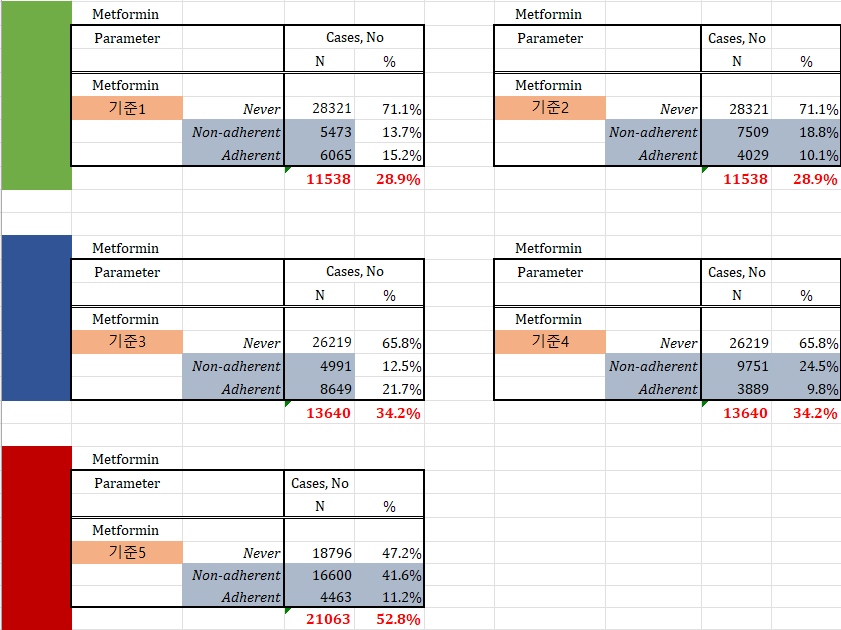

#### 인슐린 변수 정의

- 전체기간 중 한 번이라도 처방 받은 기록이 있는 경우

```r
insulin <- t60_d[grep('Insulin', t60_d$name), ] %>%
  inner_join(t20 %>% dplyr::select(PERSON_ID, KEY_SEQ, TOT_PRES_DD_CNT)) %>%
  arrange(PERSON_ID)
length(unique(insulin$PERSON_ID))
dataframe <- dataframe %>% mutate(insul = ifelse(PERSON_ID %in% insulin$PERSON_ID, 1, 0))
table(dataframe$insul)
```